# Workshop 1 Financial Econometrics

Juan David Torres

Feb 10 2021

# Clear R Environment

Clears the R environment and changes number notation

```r
#Remove environment variables
rm(list=ls())

# To avoid scientific notation
options(scipen=999)
```

# Load quantmod library

Load the quantmod library everytime the program starts

```r
library(quantmod)
```

# Downloading prices

Use the getSymbols function to download the real data from Bitcoin

```r
getSymbols(Symbols=c("BTC-USD"), from="2017-01-01", src="yahoo", periodicity="daily")
```

[output not shown]

```
## [1] "BTC-USD"
```

# Showing the contents of Datasets

Show the content of the first 5 datasets as it is already in the global environment

```r
head(`BTC-USD`,5)
```

```
##            BTC-USD.Open BTC-USD.High BTC-USD.Low BTC-USD.Close BTC-USD.Volume
## 2017-01-01      963.658      1003.08     958.699       998.325      147775008
## 2017-01-02      998.617      1031.39     996.702      1021.750      222184992
## 2017-01-03     1021.600      1044.08    1021.600      1043.840      185168000
## 2017-01-04     1044.400      1159.42    1044.400      1154.730      344945984
## 2017-01-05     1156.730      1191.10     910.417      1013.380      510199008
##            BTC-USD.Adjusted
## 2017-01-01          998.325
## 2017-01-02         1021.750
## 2017-01-03         1043.840
## 2017-01-04         1154.730
## 2017-01-05         1013.380
```

Show the content of the last 5 datasets.

```r
tail(`BTC-USD`,5)
```

```
##            BTC-USD.Open BTC-USD.High BTC-USD.Low BTC-USD.Close BTC-USD.Volume
## 2021-02-12     47877.04     48745.73    46424.98      47504.85    76555041196
## 2021-02-13           NA           NA          NA            NA             NA
## 2021-02-14     47114.51     49487.64    47114.51      48717.29    71248675228
## 2021-02-15     48696.54     48875.57    46347.48      47945.06    77069903166
## 2021-02-16     48404.60     50335.71    47237.46      49091.71    77014908928
##            BTC-USD.Adjusted
## 2021-02-12         47504.85
## 2021-02-13               NA
## 2021-02-14         48717.29
## 2021-02-15         47945.06
## 2021-02-16         49091.71
```

# Visualization Of Prices

Plot Bitcoin price

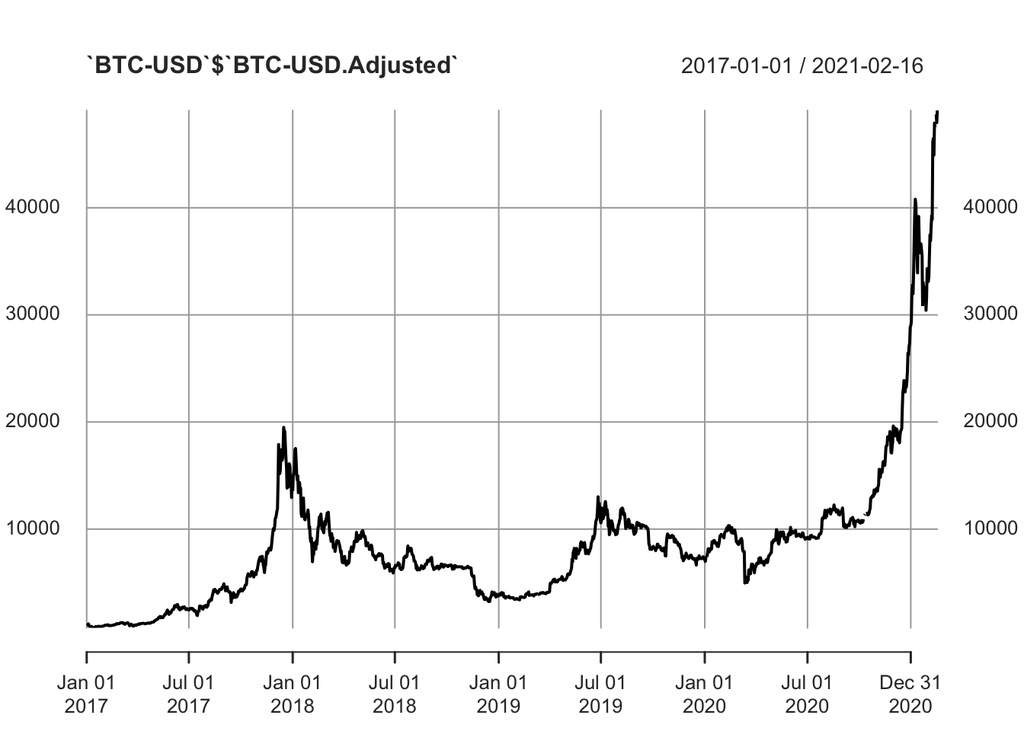

```r
plot(`BTC-USD`$ `BTC-USD.Adjusted`)
```

```r
# plot(`BTC-USD`$ `BTC-USD.Adjusted`)
```

Better way to plot the price of BTC

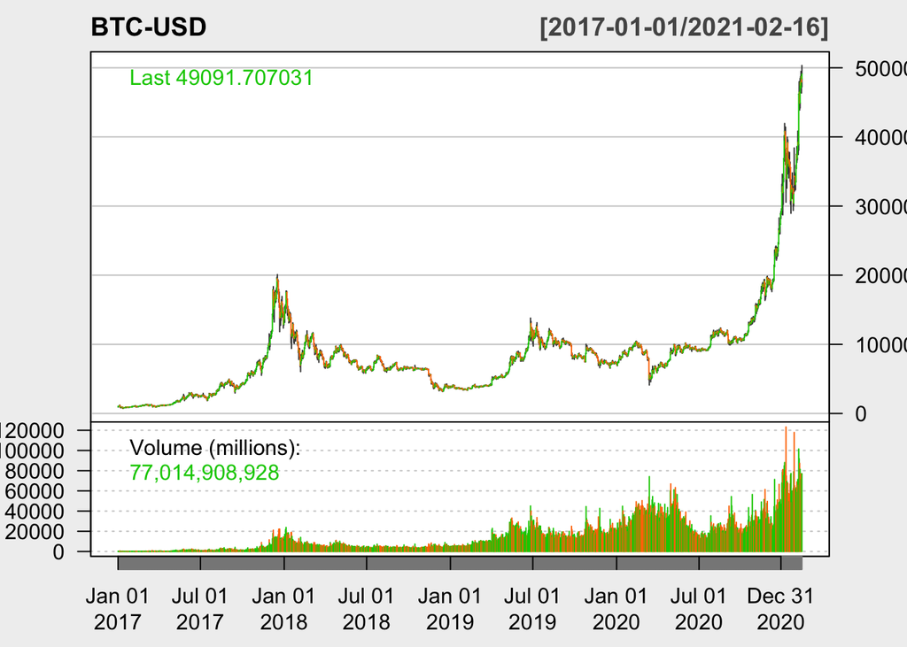

```r
chartSeries(`BTC-USD`, theme=("white"))
```

# Data Cleaning

A way to deal with empty values in the dataset by omitting NA

```r
`BTC-USD` <- na.omit(`BTC-USD`)
```

# Calculation of Financial Returns

Create a new object and assign the adjusted prices of Bitcoin

```r
prices <- Ad(`BTC-USD`)
```

Assign a column name for the adjusted prices

```r
colnames(prices) <- "adj_price"
```

Adding Returns and Lags

```r
prices$lag1 <- lag(prices$adj_price, n=1)

#Formula for the simple returns
prices$R_a <- prices$adj_price / prices$lag1 -1
# Alternative
prices$R_b <- prices$adj_price / lag(prices$adj_price, n=1) -1
```

Daily growth factor

```r
prices$GrowthR <- 1 + prices$R_a
```

Calculation of daily continuosly compounded returns

```r
prices$r_b <- log(prices$adj_price / prices$lag1)
# or
prices$r <- diff(log(prices$adj_price))
# the result must be the same for both columns
```

Daily continuos compounded returns using simple returns

```r
prices$r_from_R <- log(1 + prices$R_a)
```

Simple daily returns using ccr

```r
prices$R_from_r <- exp(prices$r)-1
```

Check the first 5 rows

```r
head(prices, 5)
```

```
##            adj_price     lag1         R_a         R_b   GrowthR         r_b
## 2017-01-01   998.325       NA          NA          NA        NA          NA
## 2017-01-02  1021.750  998.325  0.02346429  0.02346429 1.0234643  0.02319324
## 2017-01-03  1043.840 1021.750  0.02161974  0.02161974 1.0216197  0.02138934
## 2017-01-04  1154.730 1043.840  0.10623277  0.10623277 1.1062328  0.10096034
## 2017-01-05  1013.380 1154.730 -0.12240955 -0.12240955 0.8775905 -0.13057525
##                      r    r_from_R    R_from_r
## 2017-01-01          NA          NA          NA
## 2017-01-02  0.02319324  0.02319324  0.02346429
## 2017-01-03  0.02138934  0.02138934  0.02161974
## 2017-01-04  0.10096034  0.10096034  0.10623277
## 2017-01-05 -0.13057525 -0.13057525 -0.12240955
```

Plot R

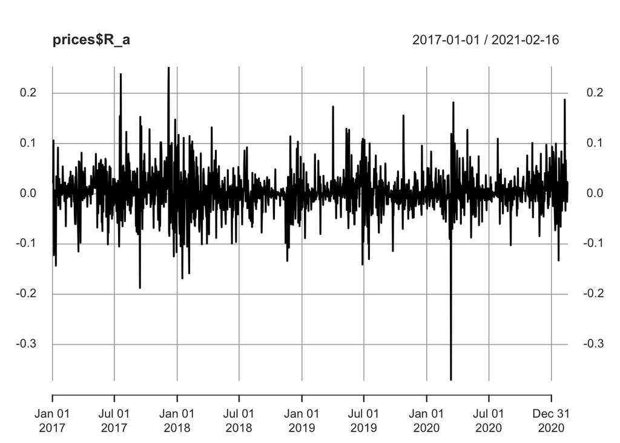

```r
plot(prices$R_a)
```

# Calculation of holding-period return

Calculate the holding-period return using initial and ending prices

```r
n <- as.numeric(nrow(prices))

price_0 <- as.numeric(prices$adj_price[1])
price_n <- as.numeric(prices$adj_price[n])

HPR1 <- (price_n / price_0) - 1
cat("HPR1 = " ,HPR1)
```

```
## HPR1 =  48.17407
```

Calculation of Holding-Period return using continuosly compounded returns

```r
sumr <- sum(prices$r, na.rm = TRUE)
HPR2 <- exp(sumr) - 1
```

HPR1 and HPR2 are the same although they are done with different methodologies

```r
cat(HPR1,HPR2)
```

```
## 48.17407 48.17407
```

# Descriptive Statistics of financial returns

Clear R environment

```r
rm(list = ls())
```

Gather Information from the Starbucks stock price

```r
getSymbols(Symbols = "SBUX", from="2008-01-01", periodicity="monthly", src="yahoo")
```

```
## [1] "SBUX"
```

Calculation of continuosly compound monthly returns

```r
returns.df <- as.data.frame((diff(log(Ad(SBUX)))))
colnames(returns.df) <- "r_SBUX"
```

# Mean, std deviation and variance of cc returns

Gather statistical information, mean, std deviation and variance of cc monthly returns

```r
summary(returns.df)
```

```
##      r_SBUX
##  Min.   :-0.38548
##  1st Qu.:-0.02706
##  Median : 0.02003
##  Mean   : 0.01649
##  3rd Qu.: 0.05767
##  Max.   : 0.26354
##  NA's   :1
```

After installing the package load it

```r
library(PerformanceAnalytics)
```

Now we can use the function stats

```r
table.Stats(returns.df$r_SBUX)
```

| Observations | 157.0000 |
| --- | --- |
| NAs | 1.0000 |
| Minimum | -0.3855 |
| Quartile 1 | -0.0271 |
| Median | 0.0200 |
| Arithmetic Mean | 0.0165 |
| Geometric Mean | 0.0134 |
| Quartile 3 | 0.0577 |
| Maximum | 0.2635 |
| SE Mean | 0.0061 |

[output cut: 6 more lines]

Also the following functions to calculate

```r
mean_r_SBUX <- mean(returns.df$r_SBUX, na.rm=TRUE) # arithmetic mean
sd_r_SBUX <- sd(returns.df$r_SBUX, na.rm=TRUE) # standard deviation
var_r_SBUX <- var(returns.df$r_SBUX, na.rm=TRUE) # variance
```

Print Arithmetic Mean

```r
cat("Mean =", mean_r_SBUX)
```

```
## Mean = 0.01649433
```

Print Standard deviation

```r
cat("Standard deviation = ", sd_r_SBUX)
```

```
## Standard deviation =  0.0769784
```

Print Variance

```r
cat("Variance = ",var_r_SBUX)
```

```
## Variance =  0.005925673
```

# Mean, std deviation and variance of simple returns

Calculation of the mean, std deviation and variance of simple monthly returns of SBUX

```r
returns.df$R_SBUX <- SBUX$SBUX.Adjusted/ lag(SBUX$SBUX.Adjusted, n=1) - 1

table.Stats(returns.df$R_SBUX)
```

| Observations | 157.0000 |
| --- | --- |
| NAs | 1.0000 |
| Minimum | -0.3199 |
| Quartile 1 | -0.0267 |
| Median | 0.0202 |
| Arithmetic Mean | 0.0196 |
| Geometric Mean | 0.0166 |
| Quartile 3 | 0.0594 |
| Maximum | 0.3015 |
| SE Mean | 0.0061 |

[output cut: 6 more lines]

Print arithmetic mean using R

```r
mean(returns.df$R_SBUX,na.rm=TRUE)
```

```
## [1] 0.01958125
```

Print std deviation using R

```r
sd(returns.df$R_SBUX,na.rm=TRUE)
```

```
## [1] 0.07703394
```

Print variance using R

```r
var(returns.df$R_SBUX,na.rm=TRUE)
```

```
##             [,1]
## [1,] 0.005934227
```

# Histogram using historical data

Do a histogram of SBUX CC Returns

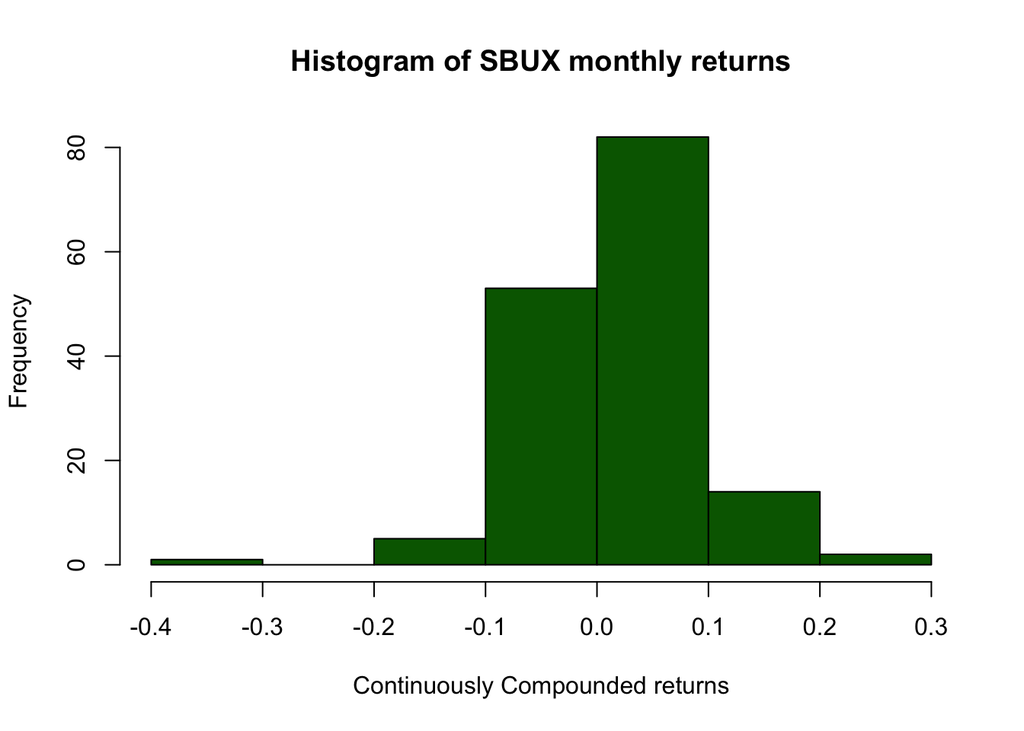

```r
hist(returns.df$r_SBUX, main="Histogram of SBUX monthly returns", xlab="Continuously Compounded returns", col="dark green")
```

Q: THIS HISTOGRAM SHOWS THAT THE CC RETURNS HAVE BEEN MORE FREQUENT BETWEEN THE 0.0 AND 0.1 AND THEN THE SECOND MOST FREQUENT VALUES HAVE BEEN FROM 0.0 TO -0.1. THIS MEANS THAT SBUX HAS GIVEN MORE POSITIVE CC RETURNS THAN NEGATIVE.

Q:THE STD DEVIATION IS A WAY IN WHICH THE SPREAD CAN BE MEASURED IN A HISTOGRAM, IS THE DEVIATION FROM THE MEAN FOR THE VALUES ON THE DATA SET. SO BASICALLY THE STD DEVIATION IS THE AVERAGE DISTANCE THE DATA HAS FROM THE MEAN.

# Histogram using simulated data for returns

Simulation of random variable using the mean and std deviation

```r
rSBUX_sim <- rnorm(n=nrow(returns.df), mean = mean_r_SBUX, sd=sd_r_SBUX)

# Get the number of rows of the object with nrow
```

Histogram of the simulated returns

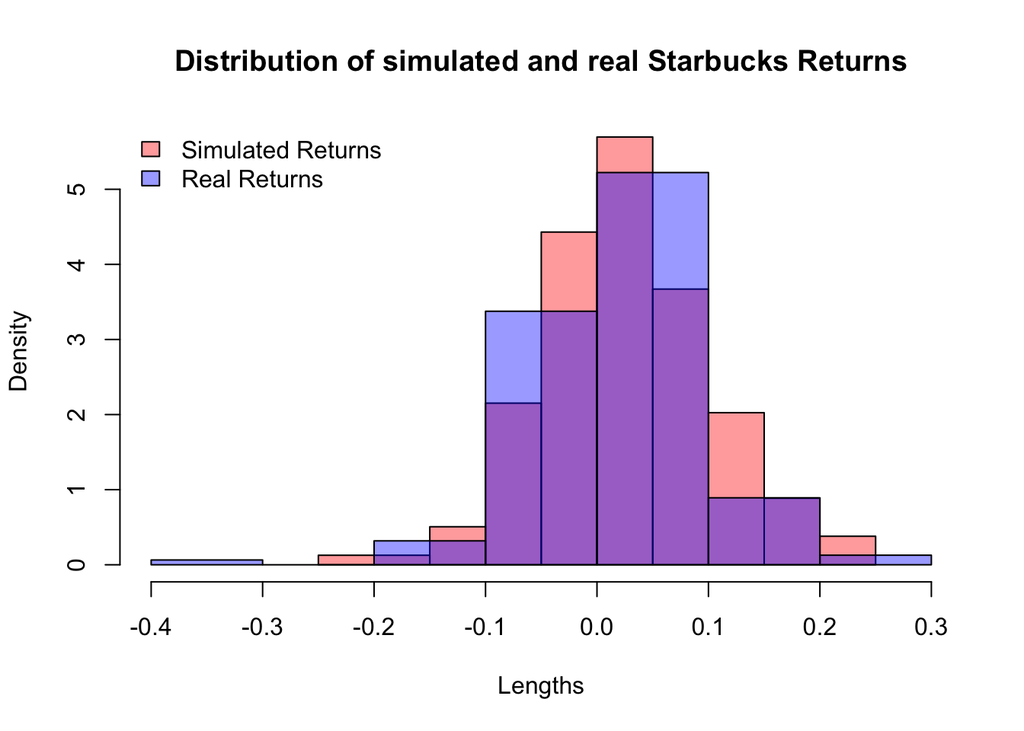

```r
#Omit any empty values
rSBUX <- na.omit(returns.df$r_SBUX)

#Calculation of histograms
hist_sim_SBUX<- hist(rSBUX_sim,plot = FALSE)
hist_SBUX <- hist(rSBUX,plot = FALSE)

# Calculate the range of the graph
xlim <- range(hist_SBUX$breaks,hist_sim_SBUX$breaks)
ylim <- range(0,hist_SBUX$density,
              hist_sim_SBUX$density)

# Plot the first histogram
plot(hist_sim_SBUX,xlim = xlim, ylim = ylim,
     col = rgb(1,0,0,0.4),xlab = 'Lengths',
     freq = FALSE, ## relative, not absolute frequency
     main = 'Distribution of simulated and real Starbucks Returns')

# Plot the second histogram on top of the 1st one
opar <- par(new = FALSE)
plot(hist_SBUX,xlim = xlim, ylim = ylim,
     xaxt = 'n', yaxt = 'n', ## don't add axes
     col = rgb(0,0,1,0.4), add = TRUE,
     freq = FALSE) ## relative, not absolute frequency

# Add a label in the corner
legend('topleft',c('Simulated Returns','Real Returns'),
       fill = rgb(1:0,0,0:1,0.4), bty = 'n')
```

Q:THE USE OF THE MEAN AND STD DEVIATION AS A WAY TO SIMULATE THE VALUES IS MUCH MORE BALANCED IN TERMS OF THE FREQUENCIES IN THE PLACES WHERE THE REAL VALUES HAVE A VERY LOW FREQUENCY THIS HAPPENDS BECAUSE IT IS USING A FORMULA TO ESTIMATE THE VALUES. ON THE OTHER HAND THE REAL VALUES AREN’T THAT BALANCED AND TEND TO BE MORE CONCENTRATED IN THE MIDDLE OF THE GRAPH IN VALUES BETWEEN 0 AND 0.1.

```r
print(mean_r_SBUX, sd_r_SBUX)
```

```
## [1] 0
```

Calculation of the confidence intervals, Z= 1.96 for 95% Confidence

```r
n <- as.numeric(nrow(returns.df))
CI_low <- mean_r_SBUX - 1.96*(sd_r_SBUX/ sqrt(n))
CI_upp <- mean_r_SBUX + 1.96*(sd_r_SBUX/ sqrt(n))
CI_low
```

```
## [1] 0.004491145
```

```r
CI_upp
```

```
## [1] 0.02849751
```